# CSE 131 Final Review

# Adder

### Syntax

```
e := <number>
  | <identifier>
  | let b in e
  | add1(e)
  | sub1(e)

b := x = e
  | x = e, b
```

# Boa

### Syntax

```
<expr> :=
  | let <bindings> in <expr>
  | if <expr>: <expr> else: <expr>
  | <binop-expr>

<binop-expr> :=
  | <number>
  | <identifier>
  | add1(<expr>)
  | sub1(<expr>)
  | <expr> + <expr>
  | <expr> - <expr>
  | <expr> * <expr>
  | ( <expr> )

<bindings> :=
  | <identifier> = <expr>
  | <identifier> = <expr>, <bindings>
```

### New Features

- Labels/Jumps/Control flow (if)
- ANF

# Boa Review (1)

Which are in ANF?

1. `2 + 3 + 4`
2. `let x = 12 in x + 1`
3. `let x = 12, y = x + 6 in x + y`
4. `let x = 12, y = 18, t = x + y + 1 in if t: 7 else: 9`

# Boa Review (2)

```
if 10:
  22
else
  33
```

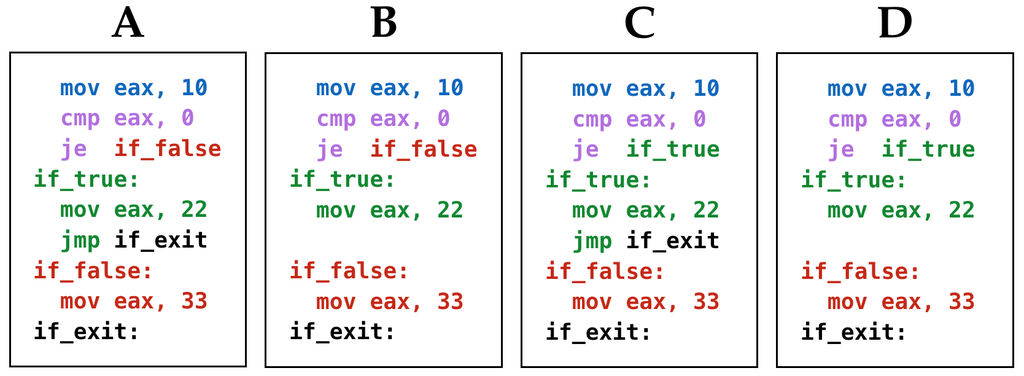

# Cobra

### Syntax

```
<expr> :=
  | let <bindings> in <expr>
  | if <expr>: <expr> else: <expr>
  | <binop-expr>

<binop-expr> :=
  | <identifier>
  | <number>
  | true
  | false
  | add1(<expr>)
  | sub1(<expr>)
  | isNum(<expr>)
  | isBool(<expr>)
  | print(<expr>)
  | <expr> + <expr>
  | <expr> - <expr>
  | <expr> * <expr>
  | <expr> < <expr>
  | <expr> > <expr>
  | <expr> == <expr>
  | ( <expr> )

<bindings> :=
  | <identifier> = <expr>
  | <identifier> = <expr>, <bindings>
```

### New Features

- Printing
  - Calling C Functions (C Stack): push old ebp, set ebp to esp
  - Returning: set esp to ebp, restore old ebp
- Type encoding
  - Use lower bits for type encoding
- Run-time errors (dynamic type checking)
  - Check bits before e.g. arithmetic operations

# Diamondback

### Syntax

```
<program> :=
  | <decls> <expr>
  | <expr>

<decls> :=
  | <decl>
  | <decl> <decls>

<decl> :=
  | def <identifier>(<ids>): <expr>
  | def <identifier>(): <expr>

<ids> :=
  | <identifier>
  | <identifier> , <ids>

<expr> :=
  | let <bindings> in <expr>
  | if <expr>: <expr> else: <expr>
  | <binop-expr>

<binop-expr> :=
  | <identifier>
  | <number>
  | true
  | false
  | add1(<expr>)
  | sub1(<expr>)
  | isnum(<expr>)
  | isbool(<expr>)
  | print(<expr>)
  | <identifier>(<exprs>)
  | <identifier>()
  | <expr> + <expr>
  | <expr> - <expr>
  | <expr> * <expr>
  | <expr> < <expr>
  | <expr> > <expr>
  | <expr> == <expr>
  | ( <expr> )

<exprs> :=
  | <expr>
  | <expr> , <exprs>

<bindings> :=
  | <identifier> = <expr>
  | <identifier> = <expr>, <bindings>
```

### New Features

- Static Error Checking (well formedness)
- Function call and application
- Tail call

# Diamondback Review

- Which sorts of errors can we check statically?
- What is the procedure for compiling a function call? A function application?
- Why do we need to do tail calls

# Diamondback Review (1)

```
def even(n):
  if (n == 0):
    true
  else:
    odd(n - 1)

def odd(n):
  if (n == 0):
    false
  else:
    even(n - 1)

let t0 = print(even(0)),
    t1 = print(even(1)),
    t2 = print(even(2)),
    t3 = print(even(3))
in
    0
```

What is the result of executing the above?

# Diamondback Review (2)

[link](https://ucsd-progsys.github.io/131-web/lectures/06-diamond.html#compiling-tail-calls-1)

```
def foo(x):
  if x == 0:
    0
  else:
    bar(x, x+1)
```

# Egg Eater

### Syntax

```
expr :=
    [ the same expressions as Diamondback ]
  | (<expr>, <expr>, <expr>, ...)
  | <expr>[<expr>]
  | isTuple(<expr>)
```

### New Features

- Heap allocated data (tuples)

### Review

- What changes would we need to make to add a new *type* to the language?

# Egg Eater Review

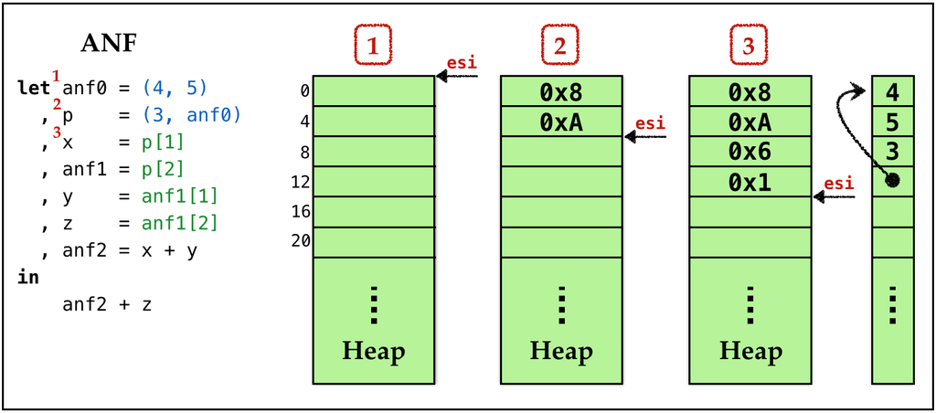

Which value does `p` get?

# Egg Eater Review

Why might go wrong if we allocate tuples (or pairs) on the stack?

```
def cons(x,y):
  (x,y)
```

# Fer de Lance

### Syntax

```
expr :=
    ...
  | (lambda <ids> : <expr>)
  | (lambda: <expr>)

ids :=
  | <id> , <ids>
  | <id>
```

### New Features

- First class and recursive functions
- Call functions with implicit first argument
- Closures

```
let f = (lambda (x): (lambda (y): x + y))
  , g = f(0) -- refers to ^^^ with x = 0
  , h = f(1) -- refers to ^^^ with x = 1
in g(1)
```

### Review:

Why can't we represent functions by

1. Code label?
2. (Arity, Label)?

Why do we need to store free variables?

How do we enable recursive function calls?

# Garter

### New Features

- Type inference: mono/polymorphic types, unification, instantiation...

# General Review

- ANF
- Arguments to primitive operations must be immediate
- Calling Convention Caller: Push args (in reverse order) Caller: Push return address (via call instruction) Callee: Push ebp Callee: `mov ebp esp` Callee: (execute function) Callee: restore `esp` (`mov esp ebp`) Callee: pop `ebp`
- Heap ** Maintain pointer to free memory in `esi` ** Ensure all addresses are values given the type encoding
- Closures ** `(#args, code pointer, free var 0, free var 1, ...)`

# References

```
e := ...
  | new e
  | set e e
  | get e
```

# Reference Behavior

```
let  x = new 0
   , y = set x 1
in
    -- should evaluate to 1
    get x
```

# AST Representation

```
data Expr = ...
          | New Expr
          | Set Expr Expr
          | Get Expr

let x = new 0 in set x (get x + 1)

Let x (New (Int 0)) (Set (Id x) (Plus (Get (Id x)) (Int 1)))
```

# ANF Question

- Which forms should be immediate?
- Which forms should be ANF?

```
let x = new 0 in set x (get x + 1)
```

ANF:

```
let x = new 0 in
let anf0 = get x in
let anf1 = anf0 + 1 in
set x anf1
```

# Code Gen

How to generate code for the following?

```
new 0

set x (get x)
```

# Type Checking

What new type forms would we need for the new expressions?

What are the typing rules for each of the new expressions?

# Exceptions

```
e := ...
  | try { e } catch x { e }
  | throw e

data Expr = ...
          | Throw Expr
          | TryCatch Expr Id Expr
```

# Exceptions

```
try { throw 0 } catch x { print(x) }
```

# Exceptions

```
try { try { throw 0 } catch x { throw x } } catch x { print(x) }
```

# Exceptions

```
try { e } catch x { m }

let x = e in
  if isEx(x) then
    m
  else
    x

0       ~~> 0x0
throw 1 ~~> 0x3

throw 0 + 1       ~~> exception 0
throw 0 + throw 2 ~~> ""     "" 0
foo(throw 1)      ~~> ""     "" 1
```

```haskell
data Either a b = Left a | Right b
```